# national_only

# 1 Sept 2021 interruption

# 2 National Data

This time we are going to run an arima using national data for females aged 15-44 who died of assault. Uploading data and converting to a tsibble object:

```r
monthly <- read.csv("../CleanData/nat_f_assault.csv")
monthly.ts <- monthly %>%
  mutate(month_year = ymd(month_year),
         month = yearmonth(month_year)) %>%
  as_tsibble(index = month)

glimpse(monthly.ts)
```

```
## Rows: 72
## Columns: 7
## $ Deaths                                   <int> 194, 149, 170, 183, 165, 182,…
## $ Crude.Rate.Lower.95..Confidence.Interval <chr> "Not Applicable", "Not Applic…
## $ Crude.Rate.Upper.95..Confidence.Interval <chr> "Not Applicable", "Not Applic…
## $ month_year                               <date> 2018-01-01, 2018-02-01, 2018…
## $ bill8                                    <lgl> FALSE, FALSE, FALSE, FALSE, F…
## $ time                                     <int> 1, 2, 3, 4, 5, 6, 7, 8, 9, 10…
## $ month                                    <mth> 2018 Jan, 2018 Feb, 2018 Mar,…
```

Looking at data, along with ACF and PACF plots:

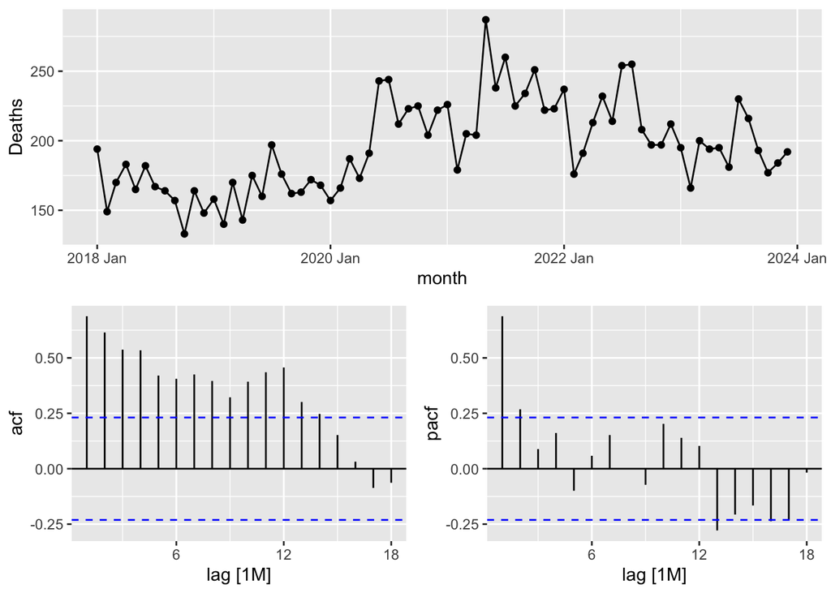

```r
monthly.ts |>
  gg_tsdisplay(y = Deaths, plot_type = "partial")
```

Looking at the PACF and ACF after differencing:

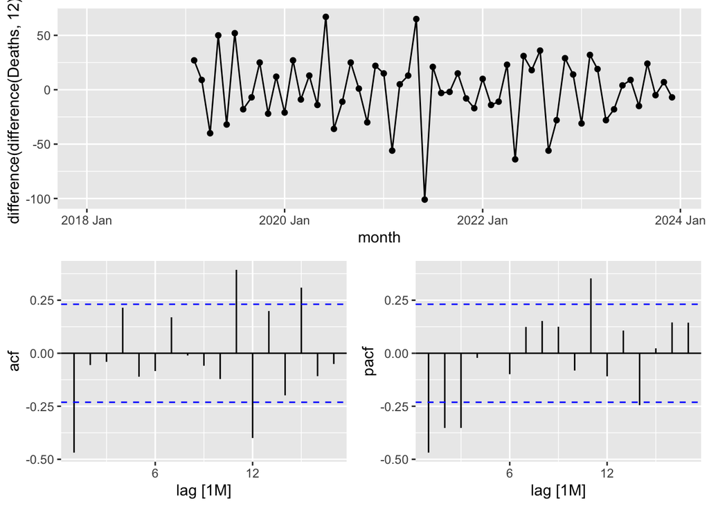

```r
monthly.ts |>
  gg_tsdisplay(y = difference(difference(Deaths,12)), plot_type = "partial")
```

Letting Fable’s ARIMA algorithm choose the best fit…

## 2.1 Intervention effects

We are capturing the intervention effects next - step and ramp variable. The first effect is captured by a step (or level shift) variable, which is a dummy variable that is 0 for all months prior to the intervention and 1 for intervention months. The second is a ramp variable, which is 0 for all months prior to the intervention and starts with 1 on the first month of the intervention and increases by 1 from there (e.g., Sep, 2021 = 1; Oct. = 2; etc…)

```r
range(monthly.ts$time)
```

```
## [1]  1 72
```

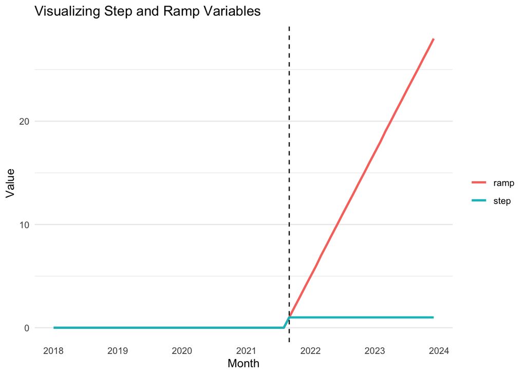

```r
# Create variable representing step and ramp changes
intervention_month <- monthly.ts %>%
  filter(month_year == "2021-09-01") %>%
  pull(time)
monthly.ts <- monthly.ts %>%
  mutate(
    t = row_number(),
    step = if_else(t >= intervention_month, 1, 0),
    ramp = if_else(t >= intervention_month, t - intervention_month + 1, 0)
  )

#View the step and ramp variables
monthly.ts %>%
  pivot_longer(
    cols = c(step, ramp),
    names_to = "variables",
    values_to = "value"
  ) %>%
  ggplot(aes(x = month_year, y = value, color = variables)) +
  geom_line(linewidth = 1) +
  geom_vline(
    xintercept = as.Date("2021-09-01"),
    linetype = "dashed",
    color = "black"
  ) +
  labs(
    title = "Visualizing Step and Ramp Variables",
    x = "Month",
    y = "Value",
    color = ""
  ) +
  scale_x_date(date_breaks = "1 year", date_labels = "%Y") +
  theme_minimal() +
  theme(
    panel.grid.major.x = element_blank(),
    panel.grid.minor.x = element_blank()
  )
```

## ARIMA model

The Fable algorithm will dictate the model parameters. Next, we plot the residuals, the ACF plot, and a histogram to ensure they approximate a white noise series.

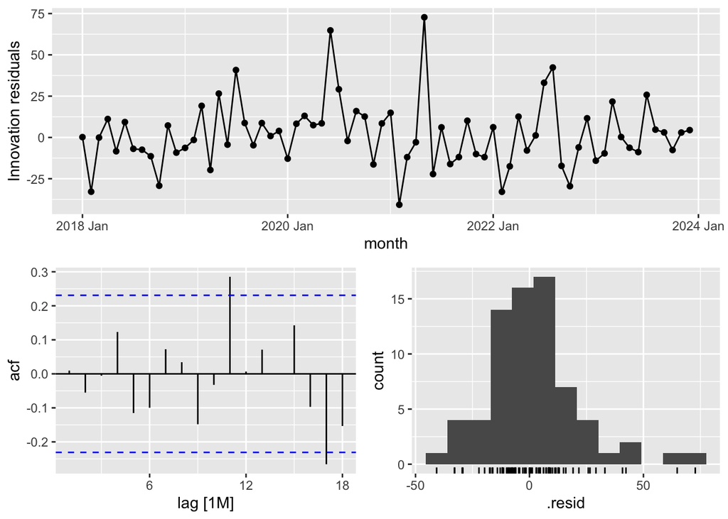

```r
# Use automated algorithm to identify p/q parameters
# Specify first difference = 1 and seasonal difference = 1
m_monthly.ts <- monthly.ts %>%
  model(arima = ARIMA(Deaths ~ step + ramp, stepwise = FALSE))

#Plotting model residuals
m_monthly.ts  %>%
  gg_tsresiduals()
```

Here we use the Ljung-Box test, which models if the residuals are still autocorrelated. Null: residuals are independent (white noise) Alternative: residuals show remaining autocorrelation

```r
#Ljung-Box test
augment(m_monthly.ts) %>%
  features(.resid, ljung_box)
```

```
## # A tibble: 1 × 3
##   .model lb_stat lb_pvalue
##   <chr>    <dbl>     <dbl>
## 1 arima  0.00675     0.935
```

With the model assumptions satisfied, we can take a look at the model estimates:

```r
report(m_monthly.ts)
```

```
## Series: Deaths
## Model: LM w/ ARIMA(0,1,1)(1,0,0)[12] errors
##
## Coefficients:
##           ma1    sar1     step     ramp
##       -0.6957  0.4574   6.9561  -2.3034
## s.e.   0.0905  0.1046  13.7508   1.6305
##
## sigma^2 estimated as 424.4:  log likelihood=-315.22
## AIC=640.43   AICc=641.36   BIC=651.75
```

This one gave us two different components! (0,1,1)(1,0,0)

It picked up **p=0**, meaning there are no autoregressive terms (the current value is not directly predicted by past raw data values).

**d=1**, meaning there is differencing; the original, raw data possesses a trend.

**q=1**: there is one moving average term, aka the model uses the error from the previous tie step to predict the current value

For seasonality, we got 1 autoregressive term.

The ARIMA estimated an immediate increase in **6.95 deaths** and an estimated reduction of **-2.30 deaths** each month after Bill 8 was enacted.

Finally, we can run a counter-factual model in which we forecast deaths for 2021-2023 given the model parameters from our initial model, minus the step and ramp parameters.

```r
#Modeling counterfactual
m_counterfactual <- monthly.ts %>%
  filter(month < make_yearmonth(2021, 9)) %>%
  model(
    arima_null = ARIMA(
      Deaths,
      stepwise = FALSE
    )
  )
report(m_counterfactual)
```

```
## Series: Deaths
## Model: ARIMA(0,1,1)(1,0,0)[12]
##
## Coefficients:
##           ma1    sar1
##       -0.6381  0.3091
## s.e.   0.1202  0.1764
##
## sigma^2 estimated as 508:  log likelihood=-194.81
## AIC=395.62   AICc=396.24   BIC=400.9
```

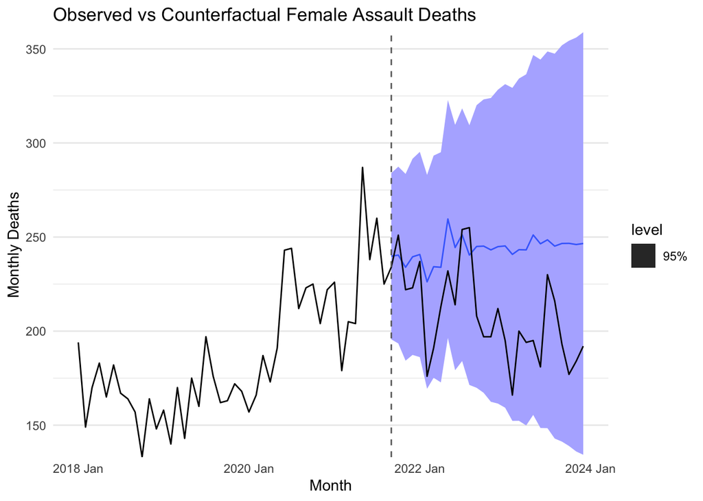

```r
#forecast into post-intervention period
fc_counterfactual <- m_counterfactual %>%
  forecast(h = 28)

 autoplot(fc_counterfactual, monthly.ts, level = 95) +
  geom_vline(
    xintercept = as.numeric(as_date(make_yearmonth(2021, 9))),
    linetype = "dashed",
    color = "grey40"
  ) +
  labs(
    title = "Observed vs Counterfactual Female Assault Deaths",
    y = "Monthly Deaths",
    x = "Month"
  ) +
  scale_y_continuous(expand = c(0, 0)) +
  theme_minimal() +
  theme(
    panel.grid.major.x = element_blank(),
    panel.grid.minor.x = element_blank()
  )
```

No points popping out of forecast.

# 3 May 21

This time we are going to run an arima using **national** data for females aged 15-44 who died of assault. Uploading data and converting to a tsibble object:

```r
monthly <- read.csv("../CleanData/nat_f_assault.csv")
monthly.ts <- monthly %>%
  mutate(month_year = ymd(month_year),
         month = yearmonth(month_year)) %>%
  as_tsibble(index = month)

glimpse(monthly.ts)
```

```
## Rows: 72
## Columns: 7
## $ Deaths                                   <int> 194, 149, 170, 183, 165, 182,…
## $ Crude.Rate.Lower.95..Confidence.Interval <chr> "Not Applicable", "Not Applic…
## $ Crude.Rate.Upper.95..Confidence.Interval <chr> "Not Applicable", "Not Applic…
## $ month_year                               <date> 2018-01-01, 2018-02-01, 2018…
## $ bill8                                    <lgl> FALSE, FALSE, FALSE, FALSE, F…
## $ time                                     <int> 1, 2, 3, 4, 5, 6, 7, 8, 9, 10…
## $ month                                    <mth> 2018 Jan, 2018 Feb, 2018 Mar,…
```

Looking at data, along with ACF and PACF plots:

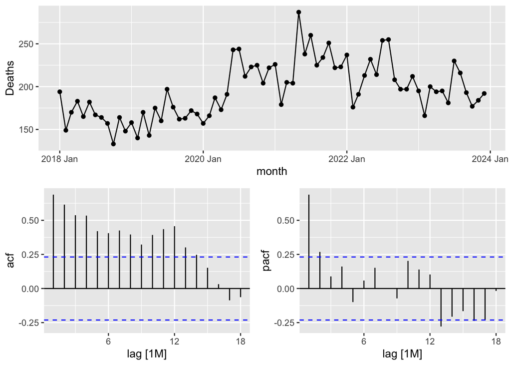

```r
monthly.ts |>
  gg_tsdisplay(y = Deaths, plot_type = "partial")
```

Looking at the PACF and ACF after differencing:

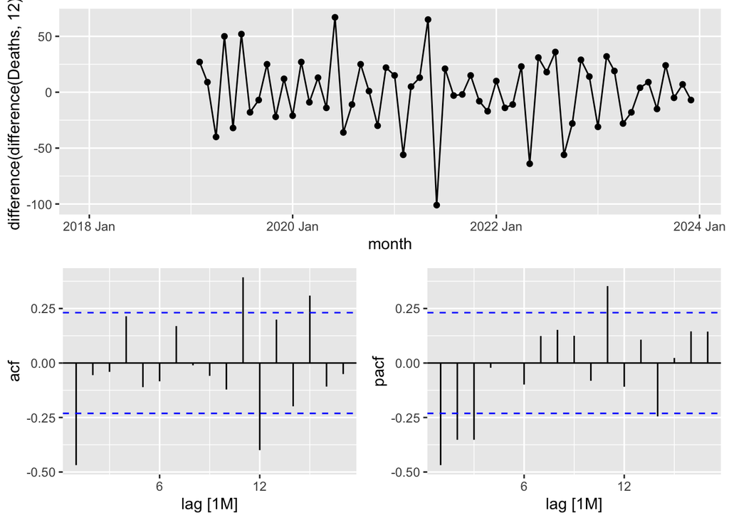

```r
monthly.ts |>
  gg_tsdisplay(y = difference(difference(Deaths,12)), plot_type = "partial")
```

Letting Fable’s ARIMA algorithm choose the best fit…

## 3.1 Intervention effects

We are capturing the intervention effects next - step and ramp variable.

```r
range(monthly.ts$time)
```

```
## [1]  1 72
```

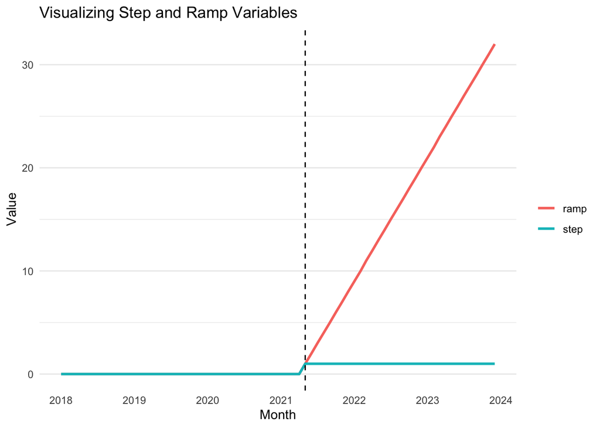

```r
# Create variable representing step and ramp changes
intervention_month <- monthly.ts %>%
  filter(month_year == "2021-05-01") %>%
  pull(time)
monthly.ts <- monthly.ts %>%
  mutate(
    t = row_number(),
    step = if_else(t >= intervention_month, 1, 0),
    ramp = if_else(t >= intervention_month, t - intervention_month + 1, 0)
  )

#View the step and ramp variables
monthly.ts %>%
  pivot_longer(
    cols = c(step, ramp),
    names_to = "variables",
    values_to = "value"
  ) %>%
  ggplot(aes(x = month_year, y = value, color = variables)) +
  geom_line(linewidth = 1) +
  geom_vline(
    xintercept = as.Date("2021-05-01"),
    linetype = "dashed",
    color = "black"
  ) +
  labs(
    title = "Visualizing Step and Ramp Variables",
    x = "Month",
    y = "Value",
    color = ""
  ) +
  scale_x_date(date_breaks = "1 year", date_labels = "%Y") +
  theme_minimal() +
  theme(
    panel.grid.major.x = element_blank(),
    panel.grid.minor.x = element_blank()
  )
```

## 3.2 ARIMA model

The Fable algorithm will dictate the model parameters. Next, we plot the residuals, the ACF plot, and a histogram to ensure they approximate a white noise series.

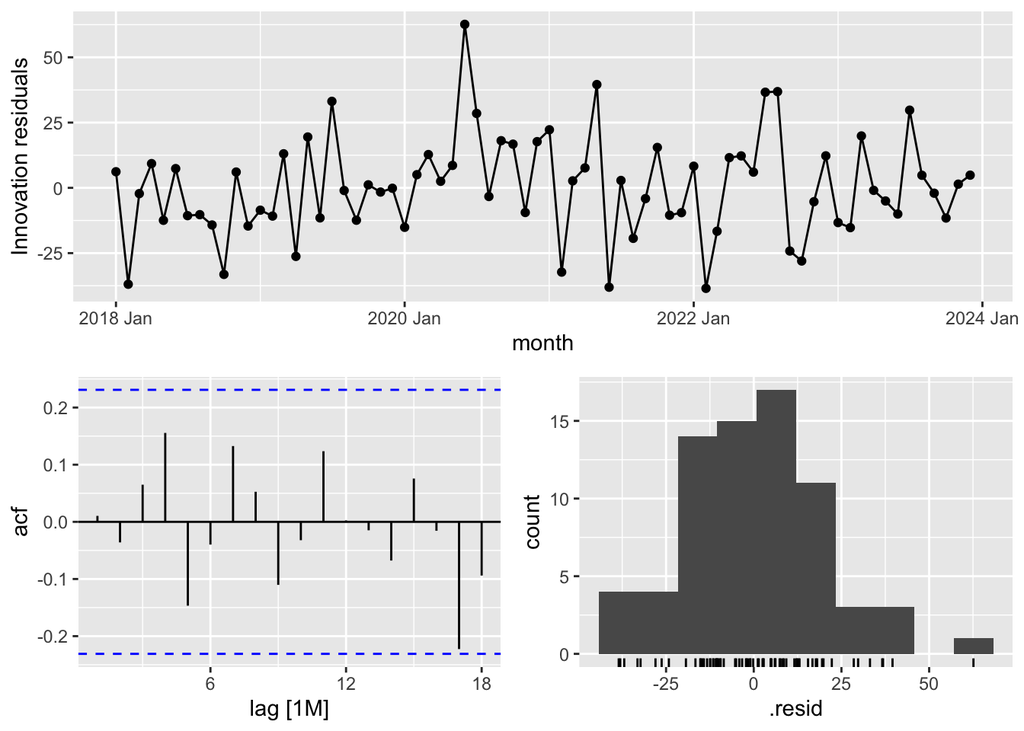

```r
# Use automated algorithm to identify p/q parameters
# Specify first difference = 1 and seasonal difference = 1
m_monthly.ts <- monthly.ts %>%
  model(arima = ARIMA(Deaths ~ step + ramp, stepwise = FALSE))

#Plotting model residuals
m_monthly.ts  %>%
  gg_tsresiduals()
```

Here we use the Ljung-Box test, which models if the residuals are still autocorrelated. Null: residuals are independent (white noise) Alternative: residuals show remaining autocorrelation

```r
#Ljung-Box test
augment(m_monthly.ts) %>%
  features(.resid, ljung_box)
```

```
## # A tibble: 1 × 3
##   .model lb_stat lb_pvalue
##   <chr>    <dbl>     <dbl>
## 1 arima  0.00814     0.928
```

Fail to reject the null.

With the model assumptions satisfied, we can take a look at the model estimates:

```r
report(m_monthly.ts)
```

```
## Series: Deaths
## Model: LM w/ ARIMA(1,0,1)(1,0,0)[12] errors
##
## Coefficients:
##          ar1      ma1    sar1     step     ramp  intercept
##       0.8675  -0.5009  0.3416  45.6645  -1.5302   185.5005
## s.e.  0.0864   0.1613  0.1286  18.3308   0.9037    14.0932
##
## sigma^2 estimated as 400:  log likelihood=-315.8
## AIC=645.6   AICc=647.35   BIC=661.54
```

It picked up **p=1**, meaning there is one autoregressive term

**d=0**, meaning there is no differencing; the original, raw data is stationary, possessing no trend.

**q=1**: there is one moving average term, aka the model uses the error from the previous tie step to predict the current value

Seasonality: 1 autoregressive term.

The ARIMA estimated an immediate increase in **45.66 deaths** and an estimated reduction of **-1.5 deaths** each month after Bill 8 was enacted.

```r
#Modeling counterfactual
m_counterfactual <- monthly.ts %>%
  filter(month < make_yearmonth(2021, 5)) %>%
  model(
    arima_null = ARIMA(
      Deaths,
      stepwise = FALSE
    )
  )
report(m_counterfactual)
```

```
## Series: Deaths
## Model: ARIMA(0,1,1)
##
## Coefficients:
##           ma1
##       -0.5130
## s.e.   0.1328
##
## sigma^2 estimated as 393.2:  log likelihood=-171.48
## AIC=346.97   AICc=347.3   BIC=350.29
```

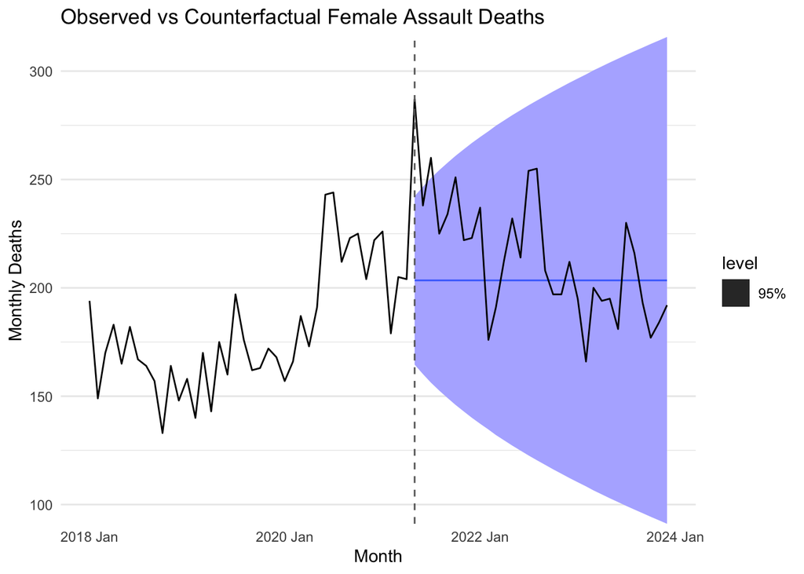

```r
#forecast into post-intervention period
fc_counterfactual <- m_counterfactual %>%
  forecast(h = 28+4)

 autoplot(fc_counterfactual, monthly.ts, level = 95) +
  geom_vline(
    xintercept = as.numeric(as_date(make_yearmonth(2021, 5))),
    linetype = "dashed",
    color = "grey40"
  ) +
  labs(
    title = "Observed vs Counterfactual Female Assault Deaths",
    y = "Monthly Deaths",
    x = "Month"
  ) +
  scale_y_continuous(expand = c(0, 0)) +
  theme_minimal() +
  theme(
    panel.grid.major.x = element_blank(),
    panel.grid.minor.x = element_blank()
  )
```